# Willamette Falls Fish Passage Time Series Analysis

Logan Ossentjuk

# Overview

This report visualizes data collected from Columbia Barin Research’s Data Access in Real Time (DART). The data utilizes is a collection of fish passages through the Willamette Falls Fish Ladder organized by species from 2001-2010. A time series is created for Coho, Jack Coho, and Steelhead salmon to understand how their population runs have changed over time. A season plot is shown to demonstrate their differing run times. Lastly, annual counts are shown to demonstrate how population abundance shifted over a ten year period.

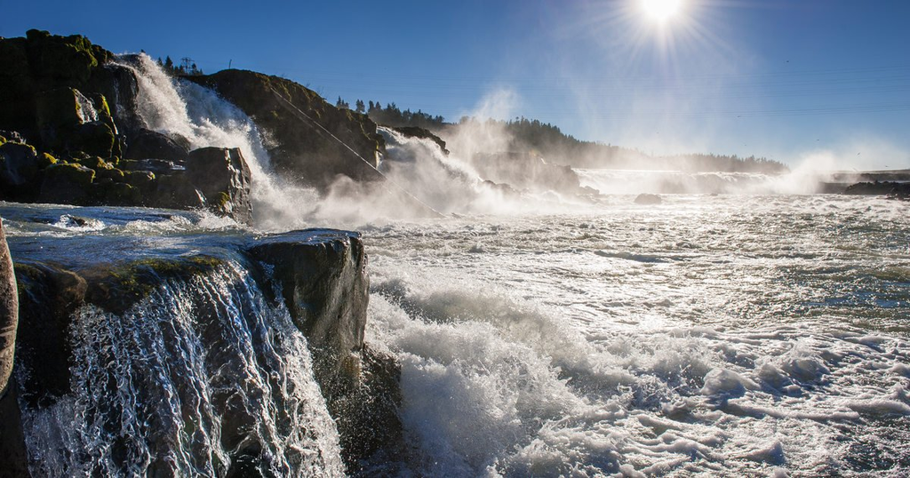

Willamette Falls, 2014. Photo by: Yuxing Zheng, Metro News

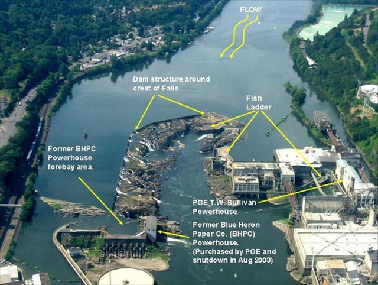

Willamette Fish Ladder, 2012. Photo by: mapking, Geocaching

**Data Citation:** DART Adult Passage Graphics & Text | Columbia Basin Research. (2012). http://www.cbr.washington.edu/dart/query/adult_graph_text

```r
knitr::opts_chunk$set(echo = TRUE, warning = FALSE, message = FALSE)
library(tidyverse)
library(here)
library(lubridate)
library(janitor)
library(tsibble)
library(feasts)
library(slider)
library(patchwork)
library(prettydoc)
library(paletteer)
```

#### Data Preparation

```r
### Data Wrangling
willamette_fish <- read_csv(here('data', 'willamette_fish_passage.csv')) %>%
  clean_names()

fish_sub <- willamette_fish %>%
  mutate(date = mdy(date)) %>%
  as_tsibble(key = NULL, index = date)  %>%
  select(date, steelhead, coho, jack_coho, ) %>%
  replace_na(list(steelhead = 0, coho = 0, jack_coho = 0))

fish_ts <- fish_sub %>%
  pivot_longer(cols = c(steelhead, coho, jack_coho),
               names_to = 'species',
               values_to = 'count') %>%
  mutate(species = case_when(
    species == 'coho' ~ 'Coho',
    species == 'jack_coho' ~ 'Jack Coho',
    species == 'steelhead' ~ 'Steelhead'))
```